# Using lattice’s bwplot()

# Preliminaries

The function `bwplot()` makes box-and-whisker plots for numerical variables. It comes from the `lattice` package for statistical graphics, which is pre-installed with every distribution of R. Also, package `tigerstats` depends on lattice, so if you load `tigerstats`:

```r
require(tigerstats)
```

then `lattice` will be loaded as well.

# One Numerical Variable

For a box-and-whisker plot of the fastest speeds ever driven by students in the `m111survey` data frame, use the command:

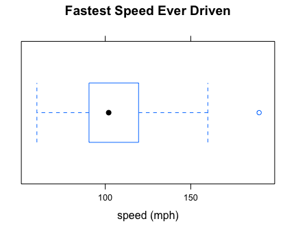

```r
bwplot(~fastest,data=m111survey,
       xlab="speed (mph)",
       main="Fastest Speed Ever Driven")
```

Note the use of:

- the `xlab` argument to label the horizontal axis, complete with units (miles per hour);
- the `main` argument to provide a brief but descriptive title for the graph.

# Numerical and Factor Variable

Say you want to know:

> *Who tends to drive faster: the guys or the gals?*

Then you are studying the relationship between the numerical variable **fastest** and the factor variable **sex**. `bwplot()` will break the fastest speeds up by sex and parallel box-and-whisker plots, if you run the following command:

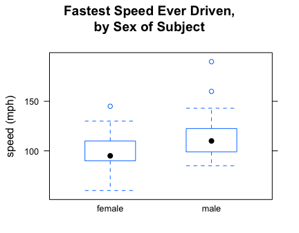

```r
bwplot(fastest~sex,data=m111survey,
       ylab="speed (mph)",
       main="Fastest Speed Ever Driven,\nby Sex of Subject")
```

If you prefer your box-and-whisker plots to be horizontal, then you can reverse the order of the variables in the formula:

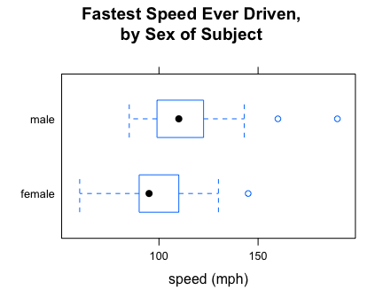

```r
bwplot(sex~fastest,data=m111survey,
       xlab="speed (mph)",
       main="Fastest Speed Ever Driven,\nby Sex of Subject")
```

# Warning

Box-and-Whisker plots are great for studying:

- one numerical variable
- the relationship between a numerical variable and a factor variable.

However, if you try to study the relationship between two numerical variables with `bwplot()`, you will get bizarre results.

For example, suppose you want to study the relationship between fastest speed ever driven (**fastest**) and the grade point average (**GPA**) of the subjects in `m111survey`:

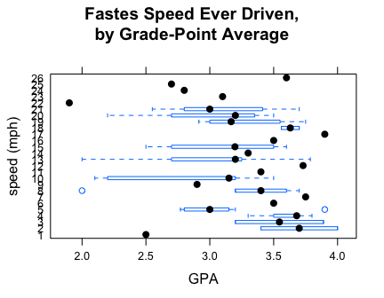

```r
bwplot(fastest~GPA,data=m111survey,
       ylab="speed (mph)",
       xbal="grade-point average",
       main="Fastes Speed Ever Driven,\nby Grade-Point Average")
```

Use `xyplot()` (scatterplots) to study the relationship between two numerical variables.